**Name:** Dixin Zhang

**Date**: 19/4/2026

**Project**: Diamond Price Prediction With Dense Neural Networks

# Step0. Import Data

```python
import kagglehub
path = kagglehub.dataset_download("shivam2503/diamonds")
```

```python
import os

print(path)
print(os.listdir(path))
```

```
C:\Users\zdxzh\.cache\kagglehub\datasets\shivam2503\diamonds\versions\1
['diamonds.csv']
```

```python
import pandas as pd

csv_path = os.path.join(path, "diamonds.csv")
df = pd.read_csv(csv_path)

df.head()
```

|  | Unnamed: 0 | carat | cut | color | clarity | depth | table | price | x | y | z |
| --- | --- | --- | --- | --- | --- | --- | --- | --- | --- | --- | --- |
| 0 | 1 | 0.23 | Ideal | E | SI2 | 61.5 | 55.0 | 326 | 3.95 | 3.98 | 2.43 |
| 1 | 2 | 0.21 | Premium | E | SI1 | 59.8 | 61.0 | 326 | 3.89 | 3.84 | 2.31 |
| 2 | 3 | 0.23 | Good | E | VS1 | 56.9 | 65.0 | 327 | 4.05 | 4.07 | 2.31 |
| 3 | 4 | 0.29 | Premium | I | VS2 | 62.4 | 58.0 | 334 | 4.20 | 4.23 | 2.63 |
| 4 | 5 | 0.31 | Good | J | SI2 | 63.3 | 58.0 | 335 | 4.34 | 4.35 | 2.75 |

```python
print(df.shape)
print(df.columns.tolist())
print(df.info())
print(df.isnull().sum())
print(df.duplicated().sum())
df.describe(include="all")
```

```
(53940, 11)
['Unnamed: 0', 'carat', 'cut', 'color', 'clarity', 'depth', 'table', 'price', 'x', 'y', 'z']
<class 'pandas.DataFrame'>
RangeIndex: 53940 entries, 0 to 53939
Data columns (total 11 columns):
 #   Column      Non-Null Count  Dtype
---  ------      --------------  -----
 0   Unnamed: 0  53940 non-null  int64
 1   carat       53940 non-null  float64
 2   cut         53940 non-null  str
 3   color       53940 non-null  str
 4   clarity     53940 non-null  str
 5   depth       53940 non-null  float64
 6   table       53940 non-null  float64
 7   price       53940 non-null  int64
 8   x           53940 non-null  float64
 9   y           53940 non-null  float64
 10  z           53940 non-null  float64
dtypes: float64(6), int64(2), str(3)
memory usage: 5.1 MB
None
Unnamed: 0    0
carat         0
cut           0
color         0
clarity       0
depth         0
table         0
price         0
x             0
y             0
z             0
dtype: int64
0
```

|  | Unnamed: 0 | carat | cut | color | clarity | depth | table | price | x | y | z |
| --- | --- | --- | --- | --- | --- | --- | --- | --- | --- | --- | --- |
| count | 53940.000000 | 53940.000000 | 53940 | 53940 | 53940 | 53940.000000 | 53940.000000 | 53940.000000 | 53940.000000 | 53940.000000 | 53940.000000 |
| unique | NaN | NaN | 5 | 7 | 8 | NaN | NaN | NaN | NaN | NaN | NaN |
| top | NaN | NaN | Ideal | G | SI1 | NaN | NaN | NaN | NaN | NaN | NaN |
| freq | NaN | NaN | 21551 | 11292 | 13065 | NaN | NaN | NaN | NaN | NaN | NaN |
| mean | 26970.500000 | 0.797940 | NaN | NaN | NaN | 61.749405 | 57.457184 | 3932.799722 | 5.731157 | 5.734526 | 3.538734 |
| std | 15571.281097 | 0.474011 | NaN | NaN | NaN | 1.432621 | 2.234491 | 3989.439738 | 1.121761 | 1.142135 | 0.705699 |
| min | 1.000000 | 0.200000 | NaN | NaN | NaN | 43.000000 | 43.000000 | 326.000000 | 0.000000 | 0.000000 | 0.000000 |
| 25% | 13485.750000 | 0.400000 | NaN | NaN | NaN | 61.000000 | 56.000000 | 950.000000 | 4.710000 | 4.720000 | 2.910000 |
| 50% | 26970.500000 | 0.700000 | NaN | NaN | NaN | 61.800000 | 57.000000 | 2401.000000 | 5.700000 | 5.710000 | 3.530000 |
| 75% | 40455.250000 | 1.040000 | NaN | NaN | NaN | 62.500000 | 59.000000 | 5324.250000 | 6.540000 | 6.540000 | 4.040000 |
| max | 53940.000000 | 5.010000 | NaN | NaN | NaN | 79.000000 | 95.000000 | 18823.000000 | 10.740000 | 58.900000 | 31.800000 |

```python
if "Unnamed: 0" in df.columns:
    df = df.drop(columns=["Unnamed: 0"])

df.head()
```

|  | carat | cut | color | clarity | depth | table | price | x | y | z |
| --- | --- | --- | --- | --- | --- | --- | --- | --- | --- | --- |
| 0 | 0.23 | Ideal | E | SI2 | 61.5 | 55.0 | 326 | 3.95 | 3.98 | 2.43 |
| 1 | 0.21 | Premium | E | SI1 | 59.8 | 61.0 | 326 | 3.89 | 3.84 | 2.31 |
| 2 | 0.23 | Good | E | VS1 | 56.9 | 65.0 | 327 | 4.05 | 4.07 | 2.31 |
| 3 | 0.29 | Premium | I | VS2 | 62.4 | 58.0 | 334 | 4.20 | 4.23 | 2.63 |
| 4 | 0.31 | Good | J | SI2 | 63.3 | 58.0 | 335 | 4.34 | 4.35 | 2.75 |

```python
target_col = "price"
num_cols = ["carat", "depth", "table", "x", "y", "z"]
cat_cols = ["cut", "color", "clarity"]

print(df[num_cols].describe())
for c in cat_cols:
    print(f"\n{c}")
    print(df[c].value_counts())
```

```
              carat         depth         table             x             y  \
count  53940.000000  53940.000000  53940.000000  53940.000000  53940.000000
mean       0.797940     61.749405     57.457184      5.731157      5.734526
std        0.474011      1.432621      2.234491      1.121761      1.142135
min        0.200000     43.000000     43.000000      0.000000      0.000000
25%        0.400000     61.000000     56.000000      4.710000      4.720000
50%        0.700000     61.800000     57.000000      5.700000      5.710000
75%        1.040000     62.500000     59.000000      6.540000      6.540000
max        5.010000     79.000000     95.000000     10.740000     58.900000

                  z
count  53940.000000
mean       3.538734
std        0.705699
min        0.000000
25%        2.910000
50%        3.530000
75%        4.040000
max       31.800000

cut
cut
Ideal        21551
Premium      13791
Very Good    12082
Good          4906
Fair          1610
Name: count, dtype: int64

color
color
G    11292
E     9797
F     9542
H     8304
D     6775
I     5422
J     2808
Name: count, dtype: int64

clarity
clarity
SI1     13065
VS2     12258
SI2      9194
VS1      8171
VVS2     5066
VVS1     3655
IF       1790
I1        741
Name: count, dtype: int64
```

# Step1 EDA/Data Wrangling

## 1.1 Univariate analysis

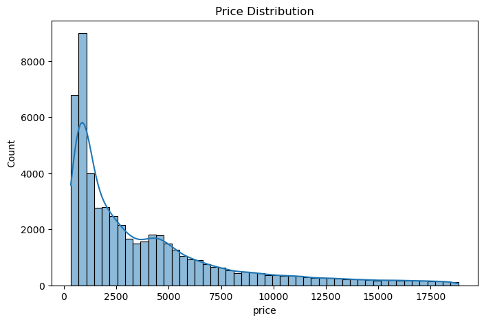

```
count    53940.000000
mean      3932.799722
std       3989.439738
min        326.000000
25%        950.000000
50%       2401.000000
75%       5324.250000
max      18823.000000
Name: price, dtype: float64
Skewness of price: 1.618395283383529
```

```python
import matplotlib.pyplot as plt
import seaborn as sns
import numpy as np

plt.figure(figsize=(8, 5))
sns.histplot(df["price"], bins=50, kde=True)
plt.title("Price Distribution")
plt.show()

print(df["price"].describe())
print("Skewness of price:", df["price"].skew())
```

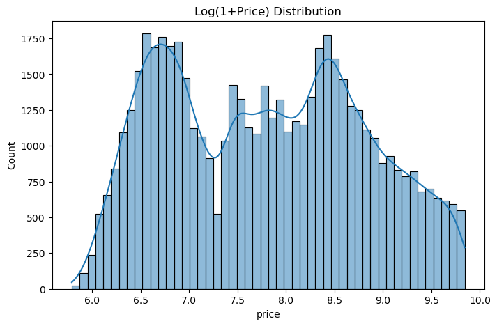

```python
plt.figure(figsize=(8, 5))
sns.histplot(np.log1p(df["price"]), bins=50, kde=True)
plt.title("Log(1+Price) Distribution")
plt.show()
```

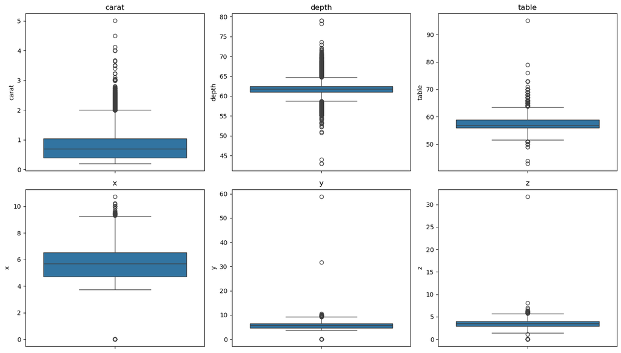

```python
plt.figure(figsize=(14, 8))
for i, col in enumerate(num_cols, 1):
    plt.subplot(2, 3, i)
    sns.boxplot(y=df[col])
    plt.title(col)
plt.tight_layout()
plt.show()
```

```python
for col in num_cols:
    print(f"\n{col}")
    print(df[col].sort_values().head(10))
    print(df[col].sort_values(ascending=False).head(10))
```

```
carat
14       0.2
31597    0.2
31596    0.2
31595    0.2
31594    0.2
31593    0.2
31592    0.2
31591    0.2
31601    0.2
31600    0.2
Name: carat, dtype: float64
27415    5.01
27630    4.50
27130    4.13
```

[output cut: 128 more lines]

```python
suspicious = df[
    (df["x"] == 0) |
    (df["y"] == 0) |
    (df["z"] == 0) |
    (df["table"] == 95) |
    (df["y"].isin([31.8, 58.9])) |
    (df["z"] == 31.8)
]

suspicious
```

|  | carat | cut | color | clarity | depth | table | price | x | y | z |
| --- | --- | --- | --- | --- | --- | --- | --- | --- | --- | --- |
| 2207 | 1.00 | Premium | G | SI2 | 59.1 | 59.0 | 3142 | 6.55 | 6.48 | 0.00 |
| 2314 | 1.01 | Premium | H | I1 | 58.1 | 59.0 | 3167 | 6.66 | 6.60 | 0.00 |
| 4791 | 1.10 | Premium | G | SI2 | 63.0 | 59.0 | 3696 | 6.50 | 6.47 | 0.00 |
| 5471 | 1.01 | Premium | F | SI2 | 59.2 | 58.0 | 3837 | 6.50 | 6.47 | 0.00 |
| 10167 | 1.50 | Good | G | I1 | 64.0 | 61.0 | 4731 | 7.15 | 7.04 | 0.00 |
| 11182 | 1.07 | Ideal | F | SI2 | 61.6 | 56.0 | 4954 | 0.00 | 6.62 | 0.00 |
| 11963 | 1.00 | Very Good | H | VS2 | 63.3 | 53.0 | 5139 | 0.00 | 0.00 | 0.00 |
| 13601 | 1.15 | Ideal | G | VS2 | 59.2 | 56.0 | 5564 | 6.88 | 6.83 | 0.00 |
| 15951 | 1.14 | Fair | G | VS1 | 57.5 | 67.0 | 6381 | 0.00 | 0.00 | 0.00 |
| 24067 | 2.00 | Premium | H | SI2 | 58.9 | 57.0 | 12210 | 8.09 | 58.90 | 8.06 |
| 24394 | 2.18 | Premium | H | SI2 | 59.4 | 61.0 | 12631 | 8.49 | 8.45 | 0.00 |
| 24520 | 1.56 | Ideal | G | VS2 | 62.2 | 54.0 | 12800 | 0.00 | 0.00 | 0.00 |
| 24932 | 2.01 | Fair | F | SI1 | 58.6 | 95.0 | 13387 | 8.32 | 8.31 | 4.87 |
| 26123 | 2.25 | Premium | I | SI1 | 61.3 | 58.0 | 15397 | 8.52 | 8.42 | 0.00 |
| 26243 | 1.20 | Premium | D | VVS1 | 62.1 | 59.0 | 15686 | 0.00 | 0.00 | 0.00 |
| 27112 | 2.20 | Premium | H | SI1 | 61.2 | 59.0 | 17265 | 8.42 | 8.37 | 0.00 |
| 27429 | 2.25 | Premium | H | SI2 | 62.8 | 59.0 | 18034 | 0.00 | 0.00 | 0.00 |
| 27503 | 2.02 | Premium | H | VS2 | 62.7 | 53.0 | 18207 | 8.02 | 7.95 | 0.00 |
| 27739 | 2.80 | Good | G | SI2 | 63.8 | 58.0 | 18788 | 8.90 | 8.85 | 0.00 |
| 48410 | 0.51 | Very Good | E | VS1 | 61.8 | 54.7 | 1970 | 5.12 | 5.15 | 31.80 |
| 49189 | 0.51 | Ideal | E | VS1 | 61.8 | 55.0 | 2075 | 5.15 | 31.80 | 5.12 |
| 49556 | 0.71 | Good | F | SI2 | 64.1 | 60.0 | 2130 | 0.00 | 0.00 | 0.00 |
| 49557 | 0.71 | Good | F | SI2 | 64.1 | 60.0 | 2130 | 0.00 | 0.00 | 0.00 |
| 51506 | 1.12 | Premium | G | I1 | 60.4 | 59.0 | 2383 | 6.71 | 6.67 | 0.00 |

## 1.2 Bivariate analysis

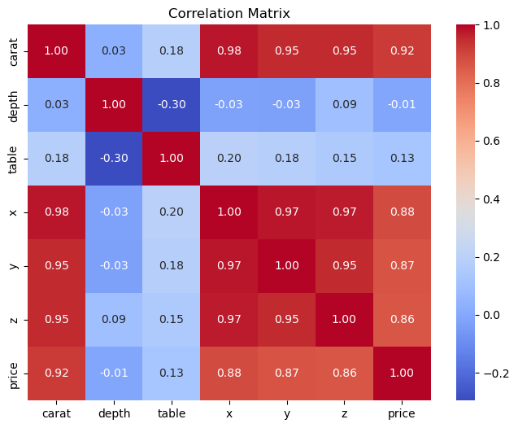

```python
corr = df[num_cols + [target_col]].corr()
plt.figure(figsize=(8, 6))
sns.heatmap(corr, annot=True, cmap="coolwarm", fmt=".2f")
plt.title("Correlation Matrix")
plt.show()
```

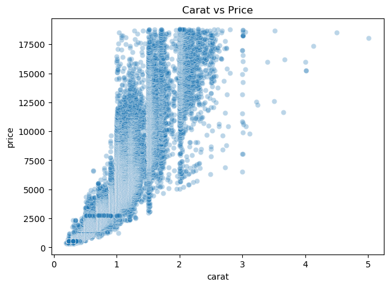

```python
plt.figure(figsize=(7, 5))
sns.scatterplot(data=df, x="carat", y="price", alpha=0.3)
plt.title("Carat vs Price")
plt.show()
```

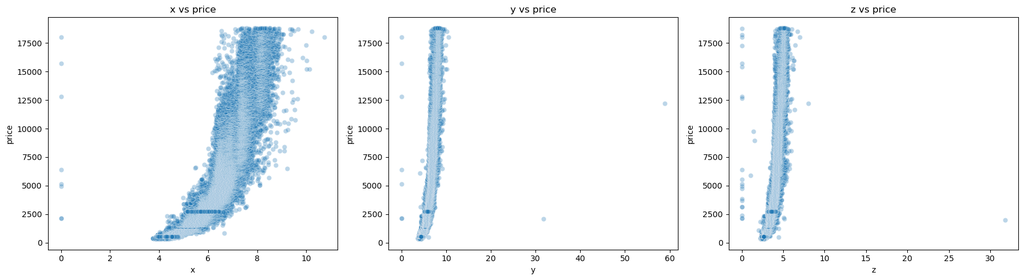

```python
fig, axes = plt.subplots(1, 3, figsize=(18, 5))

sns.scatterplot(data=df, x="x", y="price", alpha=0.3, ax=axes[0])
axes[0].set_title("x vs price")

sns.scatterplot(data=df, x="y", y="price", alpha=0.3, ax=axes[1])
axes[1].set_title("y vs price")

sns.scatterplot(data=df, x="z", y="price", alpha=0.3, ax=axes[2])
axes[2].set_title("z vs price")

plt.tight_layout()
plt.show()
```

## 1.3 Outlier investigation

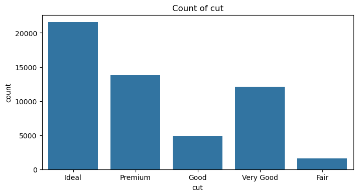

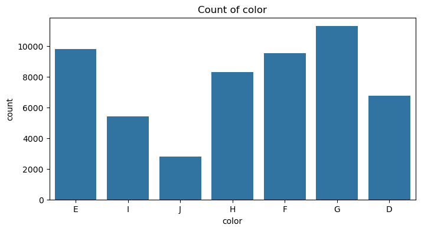

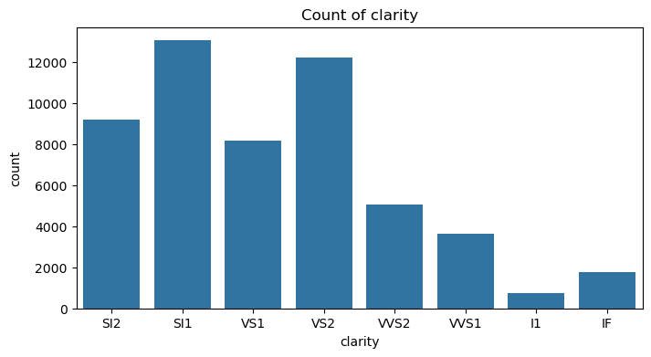

```python
for col in cat_cols:
    plt.figure(figsize=(8, 4))
    sns.countplot(data=df, x=col)
    plt.title(f"Count of {col}")
    plt.show()
```

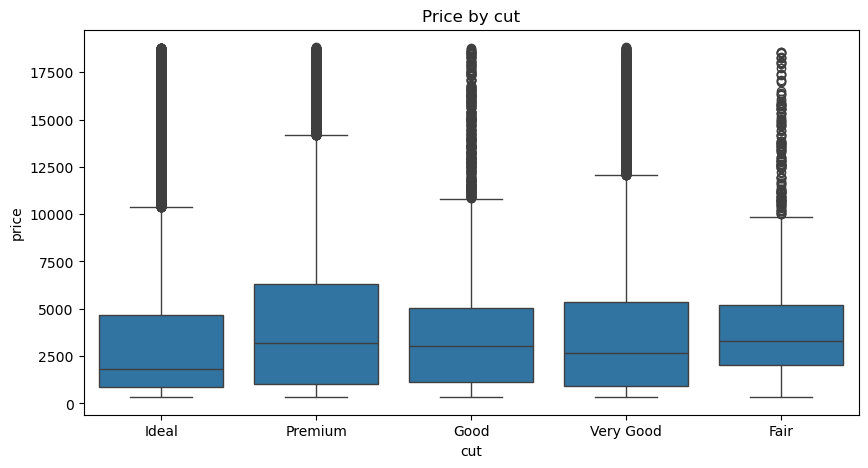

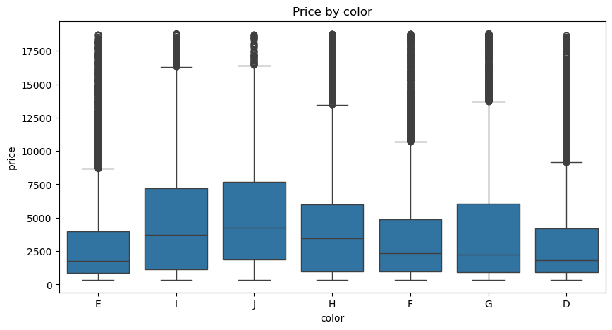

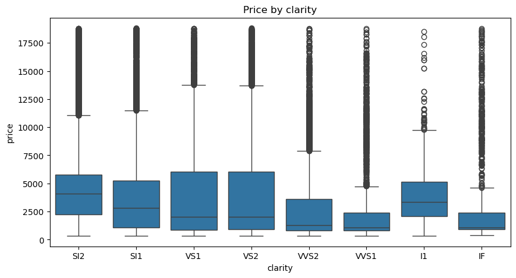

```python
for col in cat_cols:
    plt.figure(figsize=(10, 5))
    sns.boxplot(data=df, x=col, y="price")
    plt.title(f"Price by {col}")
    plt.show()
```

```python
for col in cat_cols:
    print(f"\n==== {col} ====")
    print(df.groupby(col)["price"].agg(["count", "mean", "median"]).sort_values("mean", ascending=False))
```

```
==== cut ====
           count         mean  median
cut
Premium    13791  4584.257704  3185.0
Fair        1610  4358.757764  3282.0
Very Good  12082  3981.759891  2648.0
Good        4906  3928.864452  3050.5
Ideal      21551  3457.541970  1810.0

==== color ====
       count         mean  median
color
J       2808  5323.818020  4234.0
I       5422  5091.874954  3730.0
H       8304  4486.669196  3460.0
G      11292  3999.135671  2242.0
F       9542  3724.886397  2343.5
D       6775  3169.954096  1838.0
E       9797  3076.752475  1739.0

==== clarity ====
         count         mean  median
clarity
SI2       9194  5063.028606  4072.0
SI1      13065  3996.001148  2822.0
VS2      12258  3924.989395  2054.0
I1         741  3924.168691  3344.0
VS1       8171  3839.455391  2005.0
VVS2      5066  3283.737071  1311.0
IF        1790  2864.839106  1080.0
VVS1      3655  2523.114637  1093.0
```

```python
dup_count = df.duplicated().sum()
print("Duplicated rows:", dup_count)
```

```
Duplicated rows: 146
```

```python
df[df.duplicated(keep=False)].sort_values(by=df.columns.tolist()).head(20)
```

|  | carat | cut | color | clarity | depth | table | price | x | y | z |
| --- | --- | --- | --- | --- | --- | --- | --- | --- | --- | --- |
| 43995 | 0.30 | Good | J | VS1 | 63.4 | 57.0 | 394 | 4.23 | 4.26 | 2.69 |
| 47296 | 0.30 | Good | J | VS1 | 63.4 | 57.0 | 394 | 4.23 | 4.26 | 2.69 |
| 34408 | 0.30 | Ideal | G | IF | 62.1 | 55.0 | 863 | 4.32 | 4.35 | 2.69 |
| 34422 | 0.30 | Ideal | G | IF | 62.1 | 55.0 | 863 | 4.32 | 4.35 | 2.69 |
| 28592 | 0.30 | Ideal | G | VS2 | 63.0 | 55.0 | 675 | 4.31 | 4.29 | 2.71 |
| 28593 | 0.30 | Ideal | G | VS2 | 63.0 | 55.0 | 675 | 4.31 | 4.29 | 2.71 |
| 31624 | 0.30 | Ideal | H | SI1 | 62.2 | 57.0 | 450 | 4.26 | 4.29 | 2.66 |
| 31627 | 0.30 | Ideal | H | SI1 | 62.2 | 57.0 | 450 | 4.26 | 4.29 | 2.66 |
| 31626 | 0.30 | Ideal | H | SI1 | 62.2 | 57.0 | 450 | 4.27 | 4.28 | 2.66 |
| 31629 | 0.30 | Ideal | H | SI1 | 62.2 | 57.0 | 450 | 4.27 | 4.28 | 2.66 |
| 29801 | 0.30 | Premium | D | SI1 | 62.2 | 58.0 | 709 | 4.31 | 4.28 | 2.67 |
| 29802 | 0.30 | Premium | D | SI1 | 62.2 | 58.0 | 709 | 4.31 | 4.28 | 2.67 |
| 46310 | 0.30 | Very Good | G | VS2 | 63.0 | 55.0 | 526 | 4.29 | 4.31 | 2.71 |
| 46648 | 0.30 | Very Good | G | VS2 | 63.0 | 55.0 | 526 | 4.29 | 4.31 | 2.71 |
| 43260 | 0.30 | Very Good | J | VS1 | 63.4 | 57.0 | 506 | 4.26 | 4.23 | 2.69 |
| 43261 | 0.30 | Very Good | J | VS1 | 63.4 | 57.0 | 506 | 4.26 | 4.23 | 2.69 |
| 4072 | 0.31 | Good | D | SI1 | 63.5 | 56.0 | 571 | 4.29 | 4.31 | 2.73 |
| 4386 | 0.31 | Good | D | SI1 | 63.5 | 56.0 | 571 | 4.29 | 4.31 | 2.73 |
| 30573 | 0.31 | Ideal | D | VS2 | 62.1 | 54.0 | 734 | 4.33 | 4.37 | 2.70 |
| 30577 | 0.31 | Ideal | D | VS2 | 62.1 | 54.0 | 734 | 4.33 | 4.37 | 2.70 |

```python
df = df.drop_duplicates().copy()
print(df.shape)
```

```
(53794, 10)
```

## 1.4 Data Clean

```python
df_clean = df.copy()

print("Before cleaning:", df_clean.shape)

# Remove physically unreasonable dimensions
df_clean = df_clean[(df_clean["x"] > 0) & (df_clean["y"] > 0) & (df_clean["z"] > 0)]

# Remove extreme outliers
df_clean = df_clean[df_clean["table"] != 95]
df_clean = df_clean[df_clean["y"] != 31.8]
df_clean = df_clean[df_clean["y"] != 58.9]
df_clean = df_clean[df_clean["z"] != 31.8]

print("After cleaning:", df_clean.shape)
print("Removed rows:", len(df) - len(df_clean))
```

```
Before cleaning: (53794, 10)
After cleaning: (53771, 10)
Removed rows: 23
```

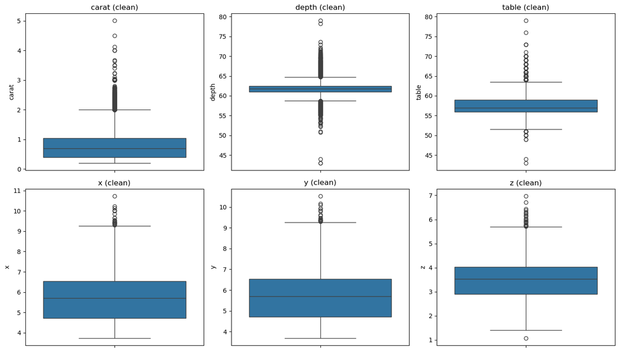

```python
plt.figure(figsize=(14, 8))
for i, col in enumerate(num_cols, 1):
    plt.subplot(2, 3, i)
    sns.boxplot(y=df_clean[col])
    plt.title(f"{col} (clean)")
plt.tight_layout()
plt.show()
```

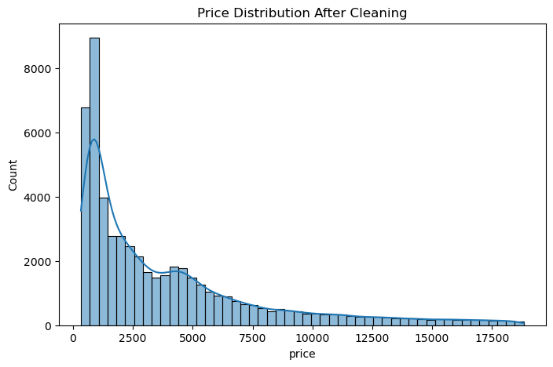

```python
plt.figure(figsize=(8, 5))
sns.histplot(df_clean["price"], bins=50, kde=True)
plt.title("Price Distribution After Cleaning")
plt.show()
```

cleaned raw dataframe

```python
df_model = df_clean.copy()
print(df_model.shape)
df_model.head()
```

```
(53771, 10)
```

|  | carat | cut | color | clarity | depth | table | price | x | y | z |
| --- | --- | --- | --- | --- | --- | --- | --- | --- | --- | --- |
| 0 | 0.23 | Ideal | E | SI2 | 61.5 | 55.0 | 326 | 3.95 | 3.98 | 2.43 |
| 1 | 0.21 | Premium | E | SI1 | 59.8 | 61.0 | 326 | 3.89 | 3.84 | 2.31 |
| 2 | 0.23 | Good | E | VS1 | 56.9 | 65.0 | 327 | 4.05 | 4.07 | 2.31 |
| 3 | 0.29 | Premium | I | VS2 | 62.4 | 58.0 | 334 | 4.20 | 4.23 | 2.63 |
| 4 | 0.31 | Good | J | SI2 | 63.3 | 58.0 | 335 | 4.34 | 4.35 | 2.75 |

EDA auxiliary column

```python
df_eda = df_clean.copy()
df_eda["log_price"] = np.log1p(df_eda["price"])
df_eda["volume"] = df_eda["x"] * df_eda["y"] * df_eda["z"]

df_eda.head()
```

|  | carat | cut | color | clarity | depth | table | price | x | y | z | log_price | volume |
| --- | --- | --- | --- | --- | --- | --- | --- | --- | --- | --- | --- | --- |
| 0 | 0.23 | Ideal | E | SI2 | 61.5 | 55.0 | 326 | 3.95 | 3.98 | 2.43 | 5.789960 | 38.202030 |
| 1 | 0.21 | Premium | E | SI1 | 59.8 | 61.0 | 326 | 3.89 | 3.84 | 2.31 | 5.789960 | 34.505856 |
| 2 | 0.23 | Good | E | VS1 | 56.9 | 65.0 | 327 | 4.05 | 4.07 | 2.31 | 5.793014 | 38.076885 |
| 3 | 0.29 | Premium | I | VS2 | 62.4 | 58.0 | 334 | 4.20 | 4.23 | 2.63 | 5.814131 | 46.724580 |
| 4 | 0.31 | Good | J | SI2 | 63.3 | 58.0 | 335 | 4.34 | 4.35 | 2.75 | 5.817111 | 51.917250 |

# Step2 Synced modeling section

This section keeps the original notebook's data loading, EDA, and cleaning, but replaces the original modeling code with the synced logic from `458_final_rebuild_sub5_notebook.ipynb`.

Important sync choices:

- use **TensorFlow / Keras** instead of PyTorch,
- evaluate with **MAPE** and **95th percentile APE**,
- keep the required **10 baseline experiments**,
- keep **stack-up exploration**,
- use the **advanced rebuild + diverse ensemble** for the final recommendation.

```python
import os
os.environ["TF_CPP_MIN_LOG_LEVEL"] = "2"

import random
import warnings
warnings.filterwarnings("ignore")

import numpy as np
import pandas as pd
import matplotlib.pyplot as plt
import seaborn as sns

from sklearn.model_selection import train_test_split
from sklearn.compose import ColumnTransformer
from sklearn.preprocessing import StandardScaler, OneHotEncoder, LabelEncoder
from sklearn.manifold import TSNE
from sklearn.metrics import mean_absolute_error, r2_score

import tensorflow as tf
from tensorflow.keras import layers, models, callbacks, regularizers, optimizers

SEED = 42
random.seed(SEED)
np.random.seed(SEED)
tf.random.set_seed(SEED)

print("TensorFlow:", tf.__version__)
```

```
TensorFlow: 2.21.0
```

```python
BASE_NUM_COLS = ["carat", "depth", "table", "x", "y", "z"]
BASE_CAT_COLS = ["cut", "color", "clarity"]

def build_preprocessor(num_cols, cat_cols):
    try:
        ohe = OneHotEncoder(drop="first", handle_unknown="ignore", sparse_output=False)
    except TypeError:
        ohe = OneHotEncoder(drop="first", handle_unknown="ignore", sparse=False)

    return ColumnTransformer(
        transformers=[
            ("num", StandardScaler(), num_cols),
            ("cat", ohe, cat_cols),
        ],
        remainder="drop",
    )

def evaluate_business_metrics(y_true, y_pred, label="Model"):
    y_true = np.asarray(y_true).astype(float).reshape(-1)
    y_pred = np.asarray(y_pred).astype(float).reshape(-1)
    ape = np.abs((y_true - y_pred) / np.clip(y_true, 1.0, None)) * 100.0
    metrics = {
        "Model": label,
        "MAE": mean_absolute_error(y_true, y_pred),
        "R2": r2_score(y_true, y_pred),
        "MAPE (%)": ape.mean(),
        "95th APE (%)": np.percentile(ape, 95),
        "Pass": bool((ape.mean() < 5.0) and (np.percentile(ape, 95) < 20.0)),
    }
    return metrics, ape

def show_business_metrics(y_true, y_pred, label="Model"):
    metrics, ape = evaluate_business_metrics(y_true, y_pred, label=label)
    print(f"\n{label}")
    print("-" * len(label))
    for k, v in metrics.items():
        if k == "Model":
            continue
        if isinstance(v, bool):
            print(f"{k}: {'PASS' if v else 'FAIL'}")
        else:
            print(f"{k}: {v:,.4f}")
    return metrics, ape

def plot_actual_vs_pred(y_true, y_pred, title):
    y_true = np.asarray(y_true).reshape(-1)
    y_pred = np.asarray(y_pred).reshape(-1)
    plt.figure(figsize=(7, 6))
    plt.scatter(y_true, y_pred, alpha=0.35)
    lims = [min(np.min(y_true), np.min(y_pred)), max(np.max(y_true), np.max(y_pred))]
    plt.plot(lims, lims, "r--")
    plt.xlabel("Actual price")
    plt.ylabel("Predicted price")
    plt.title(title)
    plt.tight_layout()
    plt.show()

def plot_percentage_error_by_price(y_true, y_pred, price_bins=10):
    y_true = np.asarray(y_true).astype(float).reshape(-1)
    y_pred = np.asarray(y_pred).astype(float).reshape(-1)
    ape = np.abs((y_true - y_pred) / np.clip(y_true, 1.0, None)) * 100.0

    plot_df = pd.DataFrame({"price": y_true, "APE": ape})
    plot_df["price_bin"] = pd.qcut(plot_df["price"], q=price_bins, duplicates="drop")
    summary = plot_df.groupby("price_bin", observed=False)["APE"].mean().reset_index()

    plt.figure(figsize=(10, 5))
    plt.plot(range(len(summary)), summary["APE"], marker="o")
    plt.xticks(range(len(summary)), [str(x) for x in summary["price_bin"]], rotation=45, ha="right")
    plt.ylabel("Mean Absolute Percentage Error (%)")
    plt.xlabel("Price bins")
    plt.title("Percentage Error by Price Bin")
    plt.tight_layout()
    plt.show()
```

## Step 2 — Baseline SNN/DNN experiments (synced to final rebuild)

These experiments use:

- cleaned data from `df_clean`,
- standard scaling for numeric features,
- one-hot encoding for categorical features,
- **log1p(price)** target,
- inverse transform back to price for business-metric evaluation.

```python
train_df, test_df = train_test_split(df_clean.copy(), test_size=0.20, random_state=SEED)

print("Train shape:", train_df.shape)
print("Test shape :", test_df.shape)
```

```
Train shape: (43016, 10)
Test shape : (10755, 10)
```

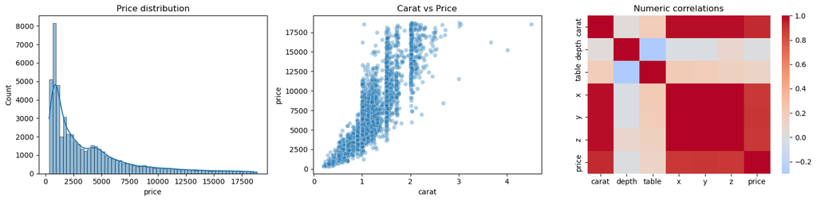

```python
fig, axes = plt.subplots(1, 3, figsize=(16, 4))
sns.histplot(df_clean["price"], bins=60, kde=True, ax=axes[0])
axes[0].set_title("Price distribution")

sns.scatterplot(
    data=df_clean.sample(min(8000, len(df_clean)), random_state=SEED),
    x="carat", y="price", alpha=0.35, ax=axes[1]
)
axes[1].set_title("Carat vs Price")

corr = df_clean[BASE_NUM_COLS + ["price"]].corr()
sns.heatmap(corr, cmap="coolwarm", center=0, ax=axes[2])
axes[2].set_title("Numeric correlations")
plt.tight_layout()
plt.show()
```

```python
baseline_train = train_df.copy()
baseline_test = test_df.copy()

baseline_train["price_log"] = np.log1p(baseline_train["price"])
baseline_test["price_log"] = np.log1p(baseline_test["price"])

pre_baseline = build_preprocessor(BASE_NUM_COLS, BASE_CAT_COLS)

X_train_baseline = pre_baseline.fit_transform(baseline_train[BASE_NUM_COLS + BASE_CAT_COLS]).astype("float32")
X_test_baseline = pre_baseline.transform(baseline_test[BASE_NUM_COLS + BASE_CAT_COLS]).astype("float32")

y_train_log = baseline_train["price_log"].values.astype("float32")
y_test_raw = baseline_test["price"].values.astype("float32")
print(X_train_baseline.shape, X_test_baseline.shape)
```

```
(43016, 23) (10755, 23)
```

```python
def build_baseline_model(input_dim, hidden_layers, dropout=0.0, use_bn=False, lr=1e-3, l2=0.0):
    model = models.Sequential()
    model.add(layers.Input(shape=(input_dim,)))
    for units in hidden_layers:
        model.add(layers.Dense(
            units,
            activation="relu",
            kernel_regularizer=regularizers.l2(l2) if l2 > 0 else None
        ))
        if use_bn:
            model.add(layers.BatchNormalization())
        if dropout and dropout > 0:
            model.add(layers.Dropout(dropout))
    model.add(layers.Dense(1))
    model.compile(optimizer=optimizers.Adam(learning_rate=lr), loss="mse")
    return model

def run_baseline_experiment(config, verbose=0):
    model = build_baseline_model(
        input_dim=X_train_baseline.shape[1],
        hidden_layers=config["layers"],
        dropout=config.get("dropout", 0.0),
        use_bn=config.get("use_bn", False),
        lr=config.get("lr", 1e-3),
        l2=config.get("l2", 0.0),
    )

    cb = [
        callbacks.EarlyStopping(monitor="val_loss", patience=20, restore_best_weights=True),
        callbacks.ReduceLROnPlateau(monitor="val_loss", factor=0.5, patience=5, min_lr=1e-5),
    ]

    history = model.fit(
        X_train_baseline,
        y_train_log,
        validation_split=0.2,
        epochs=config.get("epochs", 150),
        batch_size=config.get("batch_size", 32),
        verbose=verbose,
        callbacks=cb,
    )

    pred_log = model.predict(X_test_baseline, verbose=0).ravel()
    pred_raw = np.expm1(pred_log)
    metrics, ape = evaluate_business_metrics(y_test_raw, pred_raw, label=config["name"])
    metrics["layers"] = str(config["layers"])
    metrics["epochs_ran"] = len(history.history["loss"])
    return model, history, pred_raw, ape, metrics
```

```python
baseline_configs = [
    {"name": "Exp 1: SNN (128)", "layers": [128]},
    {"name": "Exp 2: SNN (256)", "layers": [256]},
    {"name": "Exp 3: SNN (512)", "layers": [512]},
    {"name": "Exp 4: DNN (128,64)", "layers": [128, 64]},
    {"name": "Exp 5: DNN (256,128)", "layers": [256, 128]},
    {"name": "Exp 6: DNN (256,128,64)", "layers": [256, 128, 64]},
    {"name": "Exp 7: DNN (512,256,128)", "layers": [512, 256, 128]},
    {"name": "Exp 8: DNN + BN", "layers": [256, 128, 64], "use_bn": True},
    {"name": "Exp 9: DNN + Dropout", "layers": [512, 256, 128], "dropout": 0.10},
    {"name": "Exp 10: Deep Stack (128x4)", "layers": [128, 128, 128, 128]},
]

baseline_results = []
baseline_models = {}

for cfg in baseline_configs:
    print(f"Running {cfg['name']} ...")
    model, hist, pred_raw, ape, metrics = run_baseline_experiment(cfg, verbose=0)
    baseline_results.append(metrics)
    baseline_models[cfg["name"]] = {
        "model": model,
        "history": hist,
        "pred": pred_raw,
        "ape": ape,
        "config": cfg,
    }

baseline_results_df = pd.DataFrame(baseline_results).sort_values(["MAPE (%)", "95th APE (%)"])
baseline_results_df
```

```
Running Exp 1: SNN (128) ...
WARNING:tensorflow:TensorFlow GPU support is not available on native Windows for TensorFlow >= 2.11. Even if CUDA/cuDNN are installed, GPU will not be used. Please use WSL2 or the TensorFlow-DirectML plugin.
Running Exp 2: SNN (256) ...
Running Exp 3: SNN (512) ...
Running Exp 4: DNN (128,64) ...
Running Exp 5: DNN (256,128) ...
Running Exp 6: DNN (256,128,64) ...
Running Exp 7: DNN (512,256,128) ...
Running Exp 8: DNN + BN ...
Running Exp 9: DNN + Dropout ...
Running Exp 10: Deep Stack (128x4) ...
```

|  | Model | MAE | R2 | MAPE (%) | 95th APE (%) | Pass | layers | epochs_ran |
| --- | --- | --- | --- | --- | --- | --- | --- | --- |
| 2 | Exp 3: SNN (512) | 276.887733 | 0.981778 | 6.922373 | 19.193969 | False | [512] | 150 |
| 6 | Exp 7: DNN (512,256,128) | 283.061862 | 0.980781 | 6.928806 | 18.880532 | False | [512, 256, 128] | 150 |
| 3 | Exp 4: DNN (128,64) | 279.477283 | 0.981555 | 6.993108 | 18.911166 | False | [128, 64] | 150 |
| 9 | Exp 10: Deep Stack (128x4) | 281.695564 | 0.980096 | 6.996805 | 19.615686 | False | [128, 128, 128, 128] | 68 |
| 1 | Exp 2: SNN (256) | 280.387199 | 0.981000 | 7.005372 | 19.126021 | False | [256] | 150 |
| 4 | Exp 5: DNN (256,128) | 283.390678 | 0.980566 | 7.010451 | 19.119604 | False | [256, 128] | 150 |
| 5 | Exp 6: DNN (256,128,64) | 285.325435 | 0.977856 | 7.046404 | 19.039407 | False | [256, 128, 64] | 76 |
| 0 | Exp 1: SNN (128) | 282.142992 | 0.980777 | 7.126385 | 19.309169 | False | [128] | 150 |
| 7 | Exp 8: DNN + BN | 292.361360 | 0.978059 | 7.211670 | 20.281215 | False | [256, 128, 64] | 62 |
| 8 | Exp 9: DNN + Dropout | 316.917128 | 0.977195 | 8.381012 | 22.048492 | False | [512, 256, 128] | 62 |

```
Best baseline model: Exp 3: SNN (512)

Exp 3: SNN (512)
----------------
MAE: 276.8877
R2: 0.9818
MAPE (%): 6.9224
95th APE (%): 19.1940
Pass: FAIL
```

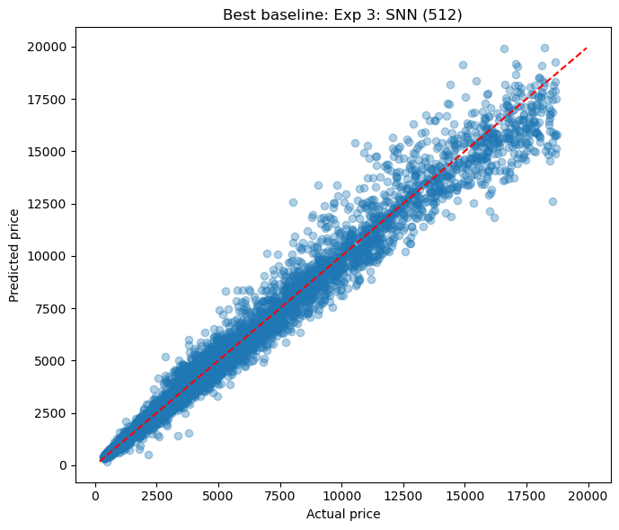

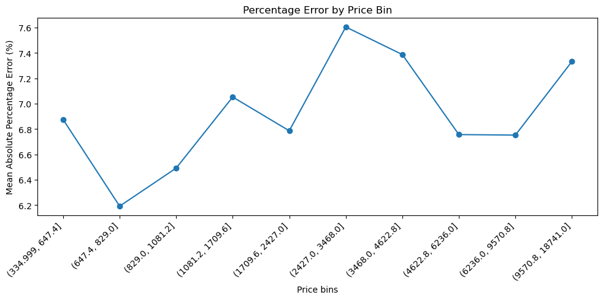

```python
best_baseline_name = baseline_results_df.iloc[0]["Model"]
best_baseline = baseline_models[best_baseline_name]

print("Best baseline model:", best_baseline_name)
show_business_metrics(y_test_raw, best_baseline["pred"], label=best_baseline_name)
plot_actual_vs_pred(y_test_raw, best_baseline["pred"], f"Best baseline: {best_baseline_name}")
plot_percentage_error_by_price(y_test_raw, best_baseline["pred"], price_bins=10)
```

## Optional — Hidden-node understanding with t-SNE

```python
try:
    dense_hidden_layers = [layer for layer in best_baseline["model"].layers if isinstance(layer, layers.Dense)]
    if len(dense_hidden_layers) >= 2:
        feature_extractor = tf.keras.Model(
            inputs=best_baseline["model"].input,
            outputs=dense_hidden_layers[-2].output
        )
        sample_n = min(2500, X_test_baseline.shape[0])
        idx = np.random.RandomState(SEED).choice(np.arange(X_test_baseline.shape[0]), size=sample_n, replace=False)
        hidden_repr = feature_extractor.predict(X_test_baseline[idx], verbose=0)

        tsne = TSNE(n_components=2, perplexity=30, random_state=SEED, init="pca", learning_rate="auto")
        z = tsne.fit_transform(hidden_repr)

        plt.figure(figsize=(8, 6))
        sc = plt.scatter(z[:, 0], z[:, 1], c=y_test_raw[idx], s=10, alpha=0.7, cmap="viridis")
        plt.colorbar(sc, label="Actual price")
        plt.title("t-SNE of last hidden layer (best baseline model)")
        plt.tight_layout()
        plt.show()
except Exception as e:
    print("t-SNE cell skipped:", e)
```

```
t-SNE cell skipped: The layer sequential_2 has never been called and thus has no defined input.
```

# Step 3 — Stack-up exploration

This synced version follows the final rebuild:

1. create `low / medium / high` tiers using training-set tertiles,
2. train a classifier for the tier,
3. train 3 tier-specific log-price regressors,
4. combine regression outputs using classifier probabilities.

```python
q1, q2 = train_df["price"].quantile([1/3, 2/3]).values

def assign_price_tier(price, low_thr=q1, high_thr=q2):
    if price < low_thr:
        return "low"
    elif price < high_thr:
        return "medium"
    return "high"

stack_train = train_df.copy()
stack_test = test_df.copy()
stack_train["price_tier"] = stack_train["price"].apply(assign_price_tier)
stack_test["price_tier"] = stack_test["price"].apply(assign_price_tier)

print("Tier thresholds:", q1, q2)
print(stack_train["price_tier"].value_counts())
```

```
Tier thresholds: 1240.0 4300.3333333333285
price_tier
medium    14349
high      14339
low       14328
Name: count, dtype: int64
```

```python
def fit_classifier_stack(train_frame):
    clf_pre = build_preprocessor(BASE_NUM_COLS, BASE_CAT_COLS)
    X_tr = clf_pre.fit_transform(train_frame[BASE_NUM_COLS + BASE_CAT_COLS]).astype("float32")
    y_tr = train_frame["price_tier"].values

    le = LabelEncoder()
    y_enc = le.fit_transform(y_tr)

    X_sub_tr, X_sub_val, y_sub_tr, y_sub_val = train_test_split(
        X_tr, y_enc, test_size=0.2, random_state=SEED, stratify=y_enc
    )

    clf = models.Sequential([
        layers.Input(shape=(X_tr.shape[1],)),
        layers.Dense(256, activation="relu"),
        layers.Dropout(0.10),
        layers.Dense(128, activation="relu"),
        layers.Dropout(0.10),
        layers.Dense(64, activation="relu"),
        layers.Dense(len(le.classes_), activation="softmax"),
    ])
    clf.compile(
        optimizer=optimizers.Adam(1e-3),
        loss="sparse_categorical_crossentropy",
        metrics=["accuracy"],
    )

    cb = [callbacks.EarlyStopping(monitor="val_loss", patience=10, restore_best_weights=True)]
    clf.fit(
        X_sub_tr, y_sub_tr,
        validation_data=(X_sub_val, y_sub_val),
        epochs=60, batch_size=64, verbose=0, callbacks=cb
    )

    val_acc = clf.evaluate(X_sub_val, y_sub_val, verbose=0)[1]
    print(f"Classifier validation accuracy: {val_acc:.4f}")
    return clf, clf_pre, le

def fit_tier_regressor(train_frame, tier_name):
    sub = train_frame[train_frame["price_tier"] == tier_name].copy()
    sub["price_log"] = np.log1p(sub["price"])

    pre = build_preprocessor(BASE_NUM_COLS, BASE_CAT_COLS)
    X_all = pre.fit_transform(sub[BASE_NUM_COLS + BASE_CAT_COLS]).astype("float32")
    y_all = sub["price_log"].values.astype("float32")

    X_sub_tr, X_sub_val, y_sub_tr, y_sub_val = train_test_split(
        X_all, y_all, test_size=0.2, random_state=SEED
    )

    model = models.Sequential([
        layers.Input(shape=(X_all.shape[1],)),
        layers.Dense(256, activation="relu"),
        layers.Dense(128, activation="relu"),
        layers.Dense(64, activation="relu"),
        layers.Dense(1),
    ])
    model.compile(optimizer=optimizers.Adam(1e-3), loss="mse")

    cb = [callbacks.EarlyStopping(monitor="val_loss", patience=12, restore_best_weights=True)]
    model.fit(
        X_sub_tr, y_sub_tr,
        validation_data=(X_sub_val, y_sub_val),
        epochs=120, batch_size=32, verbose=0, callbacks=cb
    )
    return model, pre
```

```python
clf_model, clf_pre, tier_encoder = fit_classifier_stack(stack_train)

tier_models = {}
tier_preprocessors = {}
for tier_name in ["low", "medium", "high"]:
    print("Training tier regressor:", tier_name)
    tier_model, tier_pre = fit_tier_regressor(stack_train, tier_name)
    tier_models[tier_name] = tier_model
    tier_preprocessors[tier_name] = tier_pre
```

```
Classifier validation accuracy: 0.9578
Training tier regressor: low
Training tier regressor: medium
Training tier regressor: high
```

```python
def stackup_predict(test_frame, clf_model, clf_pre, tier_encoder, tier_models, tier_preprocessors):
    X_clf = clf_pre.transform(test_frame[BASE_NUM_COLS + BASE_CAT_COLS]).astype("float32")
    probs = clf_model.predict(X_clf, verbose=0)

    tier_order = list(tier_encoder.classes_)
    tier_preds = {}
    for tier_name in tier_order:
        X_t = tier_preprocessors[tier_name].transform(test_frame[BASE_NUM_COLS + BASE_CAT_COLS]).astype("float32")
        pred_log = tier_models[tier_name].predict(X_t, verbose=0).ravel()
        tier_preds[tier_name] = np.expm1(pred_log)

    weighted_pred = np.zeros(len(test_frame))
    for j, tier_name in enumerate(tier_order):
        weighted_pred += probs[:, j] * tier_preds[tier_name]

    hard_labels = tier_encoder.inverse_transform(np.argmax(probs, axis=1))
    hard_pred = np.zeros(len(test_frame))
    for tier_name in tier_order:
        mask = hard_labels == tier_name
        hard_pred[mask] = tier_preds[tier_name][mask]

    return weighted_pred, hard_pred

stack_weighted_pred, stack_hard_pred = stackup_predict(
    stack_test, clf_model, clf_pre, tier_encoder, tier_models, tier_preprocessors
)

weighted_metrics, _ = show_business_metrics(
    stack_test["price"].values, stack_weighted_pred, label="Stack-up Weighted"
)
hard_metrics, _ = show_business_metrics(
    stack_test["price"].values, stack_hard_pred, label="Stack-up Hard Routing"
)
```

```
Stack-up Weighted
-----------------
MAE: 352.7152
R2: 0.9662
MAPE (%): 8.1902
95th APE (%): 22.3158
Pass: FAIL

Stack-up Hard Routing
---------------------
MAE: 359.6536
R2: 0.9656
MAPE (%): 8.4407
95th APE (%): 22.8738
Pass: FAIL
```

# Step 4 — Advanced rebuild for the final push

Synced changes relative to the original notebook:

- add optional extra interactions,
- drop the `log_price_per_carat` branch used in the original notebook,
- use the final rebuild's business-aligned hybrid loss,
- select models by validation MAPE / validation 95th percentile APE,
- build a **diverse top-3 ensemble**, not just multi-seed same-model averaging.

```python
def adv_build_feature_df(df_in, extra_interactions=False):
    df_feat = df_in.copy()

    cut_ord_map = {"Fair": 1, "Good": 2, "Very Good": 3, "Premium": 4, "Ideal": 5}
    color_ord_map = {"J": 1, "I": 2, "H": 3, "G": 4, "F": 5, "E": 6, "D": 7}
    clarity_ord_map = {"I1": 1, "SI2": 2, "SI1": 3, "VS2": 4, "VS1": 5, "VVS2": 6, "VVS1": 7, "IF": 8}

    df_feat["cut_ord"] = df_feat["cut"].map(cut_ord_map).astype(float)
    df_feat["color_ord"] = df_feat["color"].map(color_ord_map).astype(float)
    df_feat["clarity_ord"] = df_feat["clarity"].map(clarity_ord_map).astype(float)

    df_feat["volume"] = df_feat["x"] * df_feat["y"] * df_feat["z"]
    df_feat["face_area"] = df_feat["x"] * df_feat["y"]
    df_feat["lw_ratio"] = df_feat["x"] / np.maximum(df_feat["y"], 1e-6)
    df_feat["depth_pct_calc"] = 2.0 * df_feat["z"] / np.maximum(df_feat["x"] + df_feat["y"], 1e-6)
    df_feat["carat_sq"] = df_feat["carat"] ** 2
    df_feat["carat_cu"] = df_feat["carat"] ** 3
    df_feat["carat_x_volume"] = df_feat["carat"] * df_feat["volume"]

    if extra_interactions:
        df_feat["carat_x_cut_ord"] = df_feat["carat"] * df_feat["cut_ord"]
        df_feat["carat_x_color_ord"] = df_feat["carat"] * df_feat["color_ord"]
        df_feat["carat_x_clarity_ord"] = df_feat["carat"] * df_feat["clarity_ord"]
        df_feat["log_volume"] = np.log(np.maximum(df_feat["volume"], 1e-6))
        df_feat["xy_diff"] = np.abs(df_feat["x"] - df_feat["y"])
        df_feat["table_depth_ratio"] = df_feat["table"] / np.maximum(df_feat["depth"], 1e-6)

    return df_feat

def adv_feature_columns(extra_interactions=False):
    num_cols = [
        "carat", "depth", "table", "x", "y", "z",
        "cut_ord", "color_ord", "clarity_ord",
        "volume", "face_area", "lw_ratio", "depth_pct_calc",
        "carat_sq", "carat_cu", "carat_x_volume",
    ]
    if extra_interactions:
        num_cols += [
            "carat_x_cut_ord", "carat_x_color_ord", "carat_x_clarity_ord",
            "log_volume", "xy_diff", "table_depth_ratio",
        ]
    cat_cols = ["cut", "color", "clarity"]
    return num_cols, cat_cols

def adv_prepare_frames(train_frame, test_frame, target_mode="residual_log_carat", extra_interactions=False):
    tr = adv_build_feature_df(train_frame, extra_interactions=extra_interactions)
    te = adv_build_feature_df(test_frame, extra_interactions=extra_interactions)

    num_cols, cat_cols = adv_feature_columns(extra_interactions=extra_interactions)
    feat_cols = num_cols + cat_cols

    tr_inner, val_inner = train_test_split(tr, test_size=0.10, random_state=SEED)

    pre = build_preprocessor(num_cols, cat_cols)
    X_train = pre.fit_transform(tr_inner[feat_cols]).astype("float32")
    X_val = pre.transform(val_inner[feat_cols]).astype("float32")
    X_test = pre.transform(te[feat_cols]).astype("float32")

    y_train_raw = tr_inner["price"].values.astype("float32")
    y_val_raw = val_inner["price"].values.astype("float32")
    y_test_raw = te["price"].values.astype("float32")

    carat_train = tr_inner["carat"].values.astype("float32")
    carat_val = val_inner["carat"].values.astype("float32")
    carat_test = te["carat"].values.astype("float32")

    if target_mode == "log_price":
        a, b = 0.0, 1.0
        y_train_t = np.log1p(y_train_raw).astype("float32")
        y_val_t = np.log1p(y_val_raw).astype("float32")
    elif target_mode == "residual_log_carat":
        log_carat_train = np.log(np.maximum(carat_train, 1e-6))
        log_price_train = np.log(np.maximum(y_train_raw, 1e-6))
        b, a = np.polyfit(log_carat_train, log_price_train, deg=1)

        y_train_t = (np.log(np.maximum(y_train_raw, 1e-6)) - (a + b * np.log(np.maximum(carat_train, 1e-6)))).astype("float32")
        y_val_t = (np.log(np.maximum(y_val_raw, 1e-6)) - (a + b * np.log(np.maximum(carat_val, 1e-6)))).astype("float32")
    else:
        raise ValueError("Unsupported target_mode")

    y_train_pack = np.column_stack([y_train_t, y_train_raw, carat_train]).astype("float32")
    y_val_pack = np.column_stack([y_val_t, y_val_raw, carat_val]).astype("float32")

    return {
        "X_train": X_train, "X_val": X_val, "X_test": X_test,
        "y_train_raw": y_train_raw, "y_val_raw": y_val_raw, "y_test_raw": y_test_raw,
        "y_train_pack": y_train_pack, "y_val_pack": y_val_pack,
        "carat_val": carat_val, "carat_test": carat_test,
        "transform_a": float(a), "transform_b": float(b),
        "target_mode": target_mode,
    }

def adv_decode(pred_t, carat, target_mode, a, b):
    pred_t = np.asarray(pred_t).reshape(-1)
    carat = np.asarray(carat).reshape(-1)
    if target_mode == "log_price":
        return np.expm1(pred_t)
    elif target_mode == "residual_log_carat":
        return np.exp(pred_t + (a + b * np.log(np.maximum(carat, 1e-6))))
    else:
        raise ValueError("Unsupported target_mode")

def percentile_50_tf(x):
    x = tf.reshape(x, [-1])
    x = tf.sort(x)
    n = tf.shape(x)[0]
    k = tf.cast(tf.round(0.5 * tf.cast(n - 1, tf.float32)), tf.int32)
    return x[k]

def advanced_hybrid_loss(target_mode, a, b, alpha=0.45):
    huber = tf.keras.losses.Huber(delta=0.03)

    def loss_fn(y_true, y_pred):
        y_t = y_true[:, 0]
        y_raw = y_true[:, 1]
        carat = y_true[:, 2]
        pred_t = tf.squeeze(y_pred, axis=-1)

        if target_mode == "log_price":
            pred_raw = tf.math.expm1(pred_t)
        else:
            pred_raw = tf.exp(pred_t + (a + b * tf.math.log(tf.maximum(carat, 1e-6))))

        huber_loss = huber(y_t, pred_t)
        rel_point = tf.abs(pred_raw - y_raw) / tf.maximum(y_raw, 1.0)

        median_price = percentile_50_tf(y_raw)
        sample_w = tf.clip_by_value(median_price / tf.maximum(y_raw, 1.0), 0.8, 2.5)
        weighted_rel = tf.reduce_mean(sample_w * rel_point)

        return alpha * huber_loss + (1.0 - alpha) * weighted_rel

    return loss_fn

def build_advanced_model(input_dim, hidden_dims=(512, 256, 128, 64), dropout=0.03, wd=1e-5, lr=8e-4, activation="swish"):
    inp = layers.Input(shape=(input_dim,))
    x = inp
    for units in hidden_dims:
        x = layers.Dense(units, kernel_regularizer=regularizers.l2(wd))(x)
        x = layers.BatchNormalization()(x)
        x = layers.Activation(activation)(x)
        if dropout and dropout > 0:
            x = layers.Dropout(dropout)(x)
    out = layers.Dense(1)(x)
    model = tf.keras.Model(inp, out)
    opt = optimizers.Adam(learning_rate=lr, clipnorm=1.0)
    return model, opt
```

```python
def train_advanced_candidate(train_frame, test_frame, config, verbose=0):
    pack = adv_prepare_frames(
        train_frame,
        test_frame,
        target_mode=config["target_mode"],
        extra_interactions=config.get("extra_interactions", False),
    )

    model, opt = build_advanced_model(
        input_dim=pack["X_train"].shape[1],
        hidden_dims=config.get("hidden_dims", (512, 256, 128, 64)),
        dropout=config.get("dropout", 0.03),
        wd=config.get("weight_decay", 1e-5),
        lr=config.get("lr", 8e-4),
        activation=config.get("activation", "swish"),
    )

    model.compile(
        optimizer=opt,
        loss=advanced_hybrid_loss(
            target_mode=pack["target_mode"],
            a=pack["transform_a"],
            b=pack["transform_b"],
            alpha=config.get("alpha", 0.45),
        ),
    )

    cb = [
        callbacks.EarlyStopping(monitor="val_loss", patience=config.get("patience", 30), restore_best_weights=True),
        callbacks.ReduceLROnPlateau(monitor="val_loss", factor=0.5, patience=8, min_lr=1e-5),
    ]

    hist = model.fit(
        pack["X_train"], pack["y_train_pack"],
        validation_data=(pack["X_val"], pack["y_val_pack"]),
        epochs=config.get("epochs", 300),
        batch_size=config.get("batch_size", 256),
        verbose=verbose,
        callbacks=cb,
    )

    pred_val_t = model.predict(pack["X_val"], verbose=0).ravel()
    pred_test_t = model.predict(pack["X_test"], verbose=0).ravel()

    pred_val_raw = adv_decode(pred_val_t, pack["carat_val"], pack["target_mode"], pack["transform_a"], pack["transform_b"])
    pred_test_raw = adv_decode(pred_test_t, pack["carat_test"], pack["target_mode"], pack["transform_a"], pack["transform_b"])

    val_metrics, _ = evaluate_business_metrics(pack["y_val_raw"], pred_val_raw, label=config["name"] + " [VAL]")
    test_metrics, _ = evaluate_business_metrics(pack["y_test_raw"], pred_test_raw, label=config["name"] + " [TEST]")

    row = {
        "name": config["name"],
        "target_mode": config["target_mode"],
        "extra_interactions": config.get("extra_interactions", False),
        "alpha": config.get("alpha", 0.45),
        "dropout": config.get("dropout", 0.03),
        "weight_decay": config.get("weight_decay", 1e-5),
        "val_mape": val_metrics["MAPE (%)"],
        "val_p95": val_metrics["95th APE (%)"],
        "test_mape": test_metrics["MAPE (%)"],
        "test_p95": test_metrics["95th APE (%)"],
    }

    return {
        "config": config,
        "pack": pack,
        "model": model,
        "history": hist,
        "pred_test_raw": pred_test_raw,
        "val_metrics": val_metrics,
        "test_metrics": test_metrics,
        "row": row,
    }
```

```python
advanced_configs = [
    {"name": "Adv 1 residual base", "target_mode": "residual_log_carat", "extra_interactions": False, "alpha": 0.45, "dropout": 0.03, "weight_decay": 1e-5},
    {"name": "Adv 2 residual + extra", "target_mode": "residual_log_carat", "extra_interactions": True,  "alpha": 0.45, "dropout": 0.03, "weight_decay": 1e-5},
    {"name": "Adv 3 residual + stronger rel", "target_mode": "residual_log_carat", "extra_interactions": True, "alpha": 0.40, "dropout": 0.03, "weight_decay": 1e-5},
    {"name": "Adv 4 residual + more reg", "target_mode": "residual_log_carat", "extra_interactions": True, "alpha": 0.45, "dropout": 0.05, "weight_decay": 5e-5},
    {"name": "Adv 5 log target", "target_mode": "log_price", "extra_interactions": True, "alpha": 0.45, "dropout": 0.03, "weight_decay": 1e-5},
    {"name": "Adv 6 log target stronger rel", "target_mode": "log_price", "extra_interactions": True, "alpha": 0.40, "dropout": 0.03, "weight_decay": 1e-5},
]

advanced_runs = []
advanced_rows = []

for cfg in advanced_configs:
    print(f"Running {cfg['name']} ...")
    run = train_advanced_candidate(train_df, test_df, cfg, verbose=0)
    advanced_runs.append(run)
    advanced_rows.append(run["row"])

advanced_results_df = pd.DataFrame(advanced_rows).sort_values(["val_mape", "val_p95"])
advanced_results_df
```

```
Running Adv 1 residual base ...
Running Adv 2 residual + extra ...
Running Adv 3 residual + stronger rel ...
Running Adv 4 residual + more reg ...
Running Adv 5 log target ...
Running Adv 6 log target stronger rel ...
```

|  | name | target_mode | extra_interactions | alpha | dropout | weight_decay | val_mape | val_p95 | test_mape | test_p95 |
| --- | --- | --- | --- | --- | --- | --- | --- | --- | --- | --- |
| 3 | Adv 4 residual + more reg | residual_log_carat | True | 0.45 | 0.05 | 0.00005 | 5.878873 | 18.061602 | 6.083758 | 18.719798 |
| 2 | Adv 3 residual + stronger rel | residual_log_carat | True | 0.40 | 0.03 | 0.00001 | 5.978153 | 18.263282 | 6.174398 | 18.741543 |
| 1 | Adv 2 residual + extra | residual_log_carat | True | 0.45 | 0.03 | 0.00001 | 5.998255 | 18.399855 | 6.261281 | 19.124797 |
| 0 | Adv 1 residual base | residual_log_carat | False | 0.45 | 0.03 | 0.00001 | 5.998985 | 18.216128 | 6.197448 | 18.767595 |
| 4 | Adv 5 log target | log_price | True | 0.45 | 0.03 | 0.00001 | 9.124931 | 23.451020 | 9.757564 | 24.476926 |
| 5 | Adv 6 log target stronger rel | log_price | True | 0.40 | 0.03 | 0.00001 | 9.435607 | 24.847198 | 9.775744 | 26.003024 |

```
Best advanced candidate: Adv 4 residual + more reg

Adv 4 residual + more reg
-------------------------
MAE: 265.0907
R2: 0.9791
MAPE (%): 6.0838
95th APE (%): 18.7198
Pass: FAIL
```

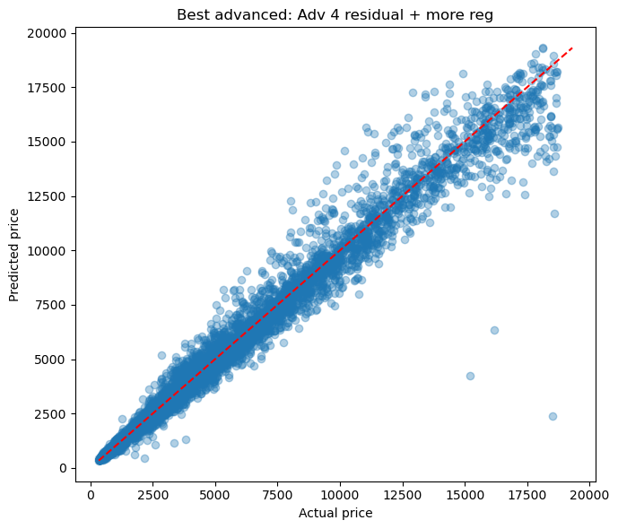

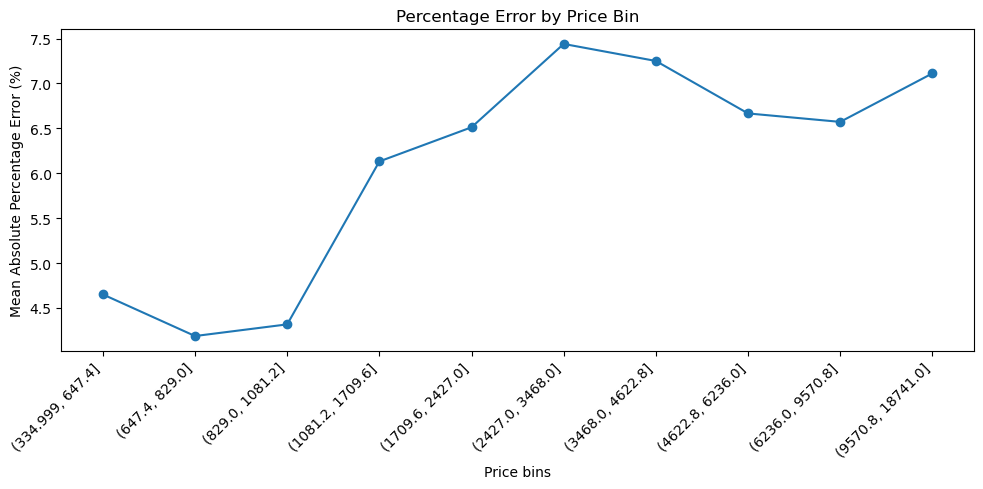

```python
best_adv_name = advanced_results_df.iloc[0]["name"]
best_adv_run = next(r for r in advanced_runs if r["config"]["name"] == best_adv_name)

print("Best advanced candidate:", best_adv_name)
show_business_metrics(best_adv_run["pack"]["y_test_raw"], best_adv_run["pred_test_raw"], label=best_adv_name)
plot_actual_vs_pred(best_adv_run["pack"]["y_test_raw"], best_adv_run["pred_test_raw"], f"Best advanced: {best_adv_name}")
plot_percentage_error_by_price(best_adv_run["pack"]["y_test_raw"], best_adv_run["pred_test_raw"], price_bins=10)
```

## Diverse ensemble

```
Ensemble members and weights:
Adv 2 residual + extra: 0.3307
Adv 3 residual + stronger rel: 0.3318
Adv 4 residual + more reg: 0.3374

Advanced Diverse Ensemble
-------------------------
MAE: 262.1346
R2: 0.9799
MAPE (%): 6.0922
95th APE (%): 18.5788
Pass: FAIL
```

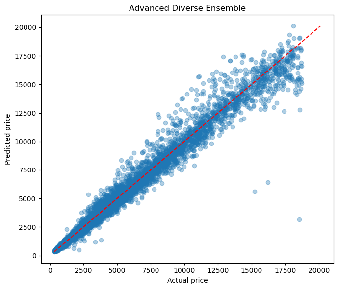

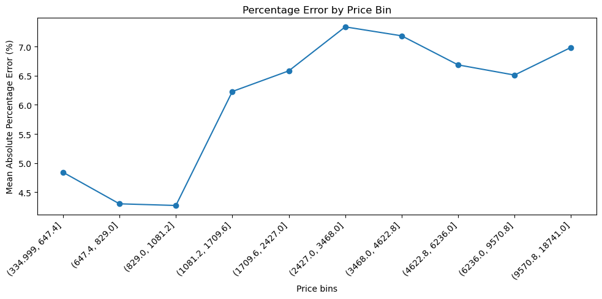

```python
top3 = advanced_results_df.head(3)["name"].tolist()
top3_runs = [r for r in advanced_runs if r["config"]["name"] in top3]

inv_scores = np.array([1.0 / max(r["val_metrics"]["MAPE (%)"], 1e-6) for r in top3_runs], dtype=float)
weights = inv_scores / inv_scores.sum()

ensemble_pred = np.zeros_like(top3_runs[0]["pred_test_raw"])
for w, run in zip(weights, top3_runs):
    ensemble_pred += w * run["pred_test_raw"]

print("Ensemble members and weights:")
for w, run in zip(weights, top3_runs):
    print(f"{run['config']['name']}: {w:.4f}")

ensemble_metrics, _ = show_business_metrics(test_df["price"].values, ensemble_pred, label="Advanced Diverse Ensemble")
plot_actual_vs_pred(test_df["price"].values, ensemble_pred, "Advanced Diverse Ensemble")
plot_percentage_error_by_price(test_df["price"].values, ensemble_pred, price_bins=10)
```

## Step 5 — Model comparison and management recommendation

```python
comparison_rows = [
    {
        "Approach": best_baseline_name,
        "MAPE (%)": evaluate_business_metrics(y_test_raw, best_baseline["pred"], best_baseline_name)[0]["MAPE (%)"],
        "95th APE (%)": evaluate_business_metrics(y_test_raw, best_baseline["pred"], best_baseline_name)[0]["95th APE (%)"],
    },
    {
        "Approach": "Stack-up Weighted",
        "MAPE (%)": weighted_metrics["MAPE (%)"],
        "95th APE (%)": weighted_metrics["95th APE (%)"],
    },
    {
        "Approach": best_adv_name,
        "MAPE (%)": best_adv_run["test_metrics"]["MAPE (%)"],
        "95th APE (%)": best_adv_run["test_metrics"]["95th APE (%)"],
    },
    {
        "Approach": "Advanced Diverse Ensemble",
        "MAPE (%)": ensemble_metrics["MAPE (%)"],
        "95th APE (%)": ensemble_metrics["95th APE (%)"],
    },
]

comparison_df = pd.DataFrame(comparison_rows).sort_values(["MAPE (%)", "95th APE (%)"]).reset_index(drop=True)
comparison_df["Business Pass"] = (comparison_df["MAPE (%)"] < 5.0) & (comparison_df["95th APE (%)"] < 20.0)
comparison_df
```

|  | Approach | MAPE (%) | 95th APE (%) | Business Pass |
| --- | --- | --- | --- | --- |
| 0 | Adv 4 residual + more reg | 6.083758 | 18.719798 | False |
| 1 | Advanced Diverse Ensemble | 6.092162 | 18.578771 | False |
| 2 | Exp 3: SNN (512) | 6.922373 | 19.193969 | False |
| 3 | Stack-up Weighted | 8.190244 | 22.315788 | False |